# Exploring the Groundwater Level Database

This script retrieves data from the in-house database. Users do not need to run this script as the processed data is available in .RData format for use in the next stage.

## Introduction

Groundwater levels in Hawke’s Bay are measured monthly, with some sites equipped with loggers that continuously record groundwater levels. However, monthly measurements are not evenly spaced, occurring anywhere between 1 to 4 weeks apart. In some cases, measurements have been taken twice within a month or missed entirely in the preceding month.

Data gaps exist for various reasons, including access issues, staff resourcing constraints, and competing monitoring commitments. Before conducting any assessments on groundwater levels, it is essential to examine the database to understand how the data is structured and how this may impact data retrieval and subsequent analysis.

### About Hilltop monitor wells

In most cases, groundwater levels are measured relative to a measuring point. However, other datums used at some sites include measurements relative to land surface, mean sea level, Hawke’s Bay datum, stage levels, and others. To minimize errors associated with changes to measuring points and to ensure groundwater levels can be compared consistently across sites, it is preferable to measure groundwater levels against a common reduced level.

### Number of sites and measurement sources

|  | Site | Measurement | StartTime | EndTime | Units | InterpolationMethod | DataType | TSType |
| --- | --- | --- | --- | --- | --- | --- | --- | --- |
| 1 | DavidsonSimpson | Depth From Measuring Point [Manual Water Level] | 27-Feb-2003 13:00:00 | 14-May-2003 12:45:00 | m | Quasi-continuous | SimpleTimeSeries | StdSeries |
| 2 | DavidsonSimpson | HB Datum minus Depth From MP [Manual Water Level] |  |  | m | Quasi-continuous | SimpleTimeSeries | StdSeries |
| 3 | DavidsonSimpson | Depth From Measuring Point [Recorder Water Level] | 27-Feb-2003 13:00:00 | 14-May-2003 12:45:00 | m | Instant | SimpleTimeSeries | StdSeries |
| 4 | Well....25 Gunns | Stage [Historic Auto Water Level] | 22-Mar-1982 16:00:00 | 26-Jul-1983 09:55:00 | m | Instant | SimpleTimeSeries | StdSeries |
| 5 | Well...113 Elmlea Farm Ltd | Depth From Measuring Point [Manual Water Level] | 19-Feb-1991 12:35:00 | 28-Jun-2000 13:35:00 | m | Quasi-continuous | SimpleTimeSeries | StdSeries |
| 6 | Well...113 Elmlea Farm Ltd | Depth From Land Surface [Manual Water Level] | 19-Feb-1991 12:35:00 | 28-Jun-2000 13:35:00 | m | Quasi-continuous | SimpleTimeSeries | StdSeries |
| 7 | Well...113 Elmlea Farm Ltd | Elevation Above Sea Level [Manual Water Level] | 19-Feb-1991 12:35:00 | 28-Jun-2000 13:35:00 | m | Quasi-continuous | SimpleTimeSeries | StdSeries |
| 8 | Well...113 Elmlea Farm Ltd | HB Datum minus Depth From MP [Manual Water Level] |  |  | m | Quasi-continuous | SimpleTimeSeries | StdSeries |
| 9 | Well...164 Wellwoods | Depth From Measuring Point [Recorder Water Level] | 29-Oct-1968 11:20:00 | 26-Aug-1986 11:30:00 | m | Instant | SimpleTimeSeries | StdSeries |
| 10 | Well...164 Wellwoods | Depth From Land Surface [Recorder Water Level] | 29-Oct-1968 11:20:00 | 26-Aug-1986 11:30:00 | m | Instant | SimpleTimeSeries | StdSeries |

[output cut: 990 more lines]

### Number of sites per measurment source

```
[1] 323
```

| Measurement | Number_of_sites |
| --- | --- |
| Depth From Measuring Point [Manual Water Level] | 323 |
| HB Datum minus Depth From MP [Manual Water Level] | 323 |
| Elevation Above Sea Level [Manual Water Level] | 249 |
| Depth From Land Surface [Manual Water Level] | 228 |
| Depth From Measuring Point [Puddle Manual Water Level] | 125 |
| Depth From Measuring Point [Recorder Water Level] | 123 |
| Elevation Above Sea Level [Recorder Water Level] | 113 |
| Depth From Land Surface [Recorder Water Level] | 102 |
| Depth From Land Surface [Puddle Manual Water Level] | 83 |
| Elevation Above Sea Level [Puddle Manual Water Level] | 82 |

[output cut: 24 more lines]

## Data Retrieval method

- Depth relative to land surface
- Depth relative to mean sea level (MSL=0), and
- Depth relative to Hawke’s Bay datum (MSL+10)

Not all sites will have groundwater levels relative to these datums. Some sites have been measured to different datums or to the same datum but with different names. This makes retrieving groundwater level information somewhat problematic.

Ideally, groundwater levels will be measured relative to a common reduced level to minimise errors caused by changes to measuring points and so groundwater levels can be compared between sites. Such changes are sometimes subtle and not easily identifiable within water level records.

Retrieving groundwater levels relative to a common reduced level is ideal when all sites are measured against the same datum. However, not all sites use the same datum, which means some useful sites may be excluded if only one datum is used for subsequent analysis. To maximise the number of sites and groundwater level data available for assessing state and trends, groundwater levels are retrieved in stages according to a hierarchy of data quality (see figure below).

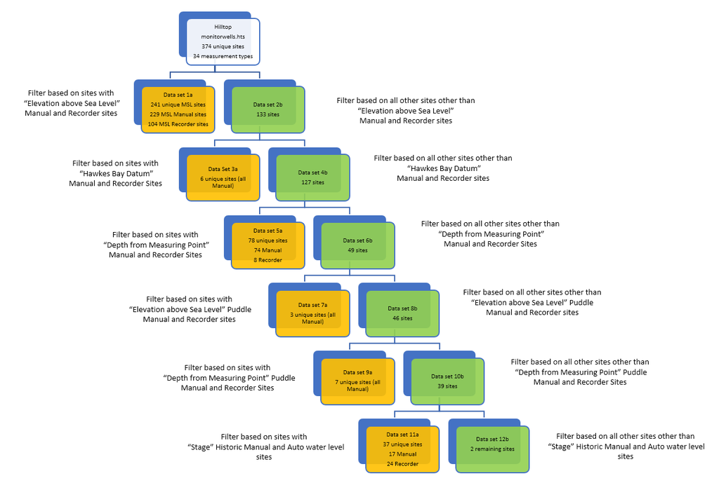

## Retrieve Data

The data is retrieved using the Hilltop R package. Loops are developed to retrieve groundwater levels. This function requires the following information

- GetData(obj, siteName, measurement, startTime, endTime, method=““, interval=”“, alignment=”“, gapTolerance=”“, WQParams=FALSE, ParamFilter=”“)

Dataframes filtered using the previously established hierarchy are used to select which sites and data to query. Groundwater levels are retrieved from both discrete (manual measurements) and continuous (recorder) datasets. These discrete and continuous data sets are then combined to form the final dataset used for state and trend analysis.

## Data Error Checking and Cleaning

A separate script has been developed for this step, which can be found at:

2_Data_error_checking_and_cleaning/data_error_checking_script.Rmd